# R Notebook

Andrei Martins e Charles Mendes

04 de Novembro de 2017

## Instalar e carregar pacotes

```r
# Instala pacotes caso ainda não tenham sido instalados
if(!require(dplyr)) install.packages("dplyr")  # Manipulação de dados
if(!require(ggplot2)) install.packages("ggplot2") # Visualização de dados
if(!require(httpuv)) install.packages("httpuv")  # Suporte a HTTP e WebSocket
if(!require(lexiconPT)) install.packages("lexiconPT")  # Análise de Sentimento
if(!require(rtweet)) install.packages("rtweet")  # Cliente para Twitter Search API
if(!require(tidytext)) install.packages("tidytext") # Mineração de textos
if(!require(wordcloud)) install.packages("wordcloud") # Visualização de textos
if(!require(RDRPOSTagger)) install.packages("RDRPOSTagger")  # Mineração de Textos
```

```
there is no package called 㤼㸱RDRPOSTagger㤼㸲
```

## Criar app no Twitter

1. Acesse https://apps.twitter.com e crie um novo aplicativo.
2. A fim demostração, no campo `Website` colocarmos a URL do nosso perfil do Twitter.
3. No campo `Callback URL` preencher com: http://127.0.0.1:1410
4. Aceite os termos e clique em “Create your Twitter application”.
5. Vá em “Keys and Access Tokens” e anote os valores dos campos `Consumer Key`, `Consumer Secret`. Eles serão utilizados para autenticação na próxima seção.
- (Ob.: Pode ser que o Twitter peça para incluir o número do seu celular, antes de criar o seu aplicativo. Só seguir as instruções: https://support.twitter.com/articles/270426.)

```r
## Nome do seu aplicativo (o mesmo criado na etapa anterior)
nomeAplicativo <- "nerdzao"

## Consumer Key (API Key)
chaveAPI <- "29lJMLodwnkMNO6guU435B5K1"

## Consumer Secret (API Secret)
chaveSecreta <- "6IIjtDyaFftDZc6E58l7mZojEmTJWnIQM2cdrA62ICFX6ZfRBm"

## Criar token para o app
twitter_token <- create_token(app = nomeAplicativo,
                              consumer_key = chaveAPI,
                              consumer_secret = chaveSecreta)
```

## Coleta de dados

Vamos coletar e preparar os dados dos *tweets* dos 4 grandes clubes paulistas (Corinthians, Palmeiras, Santos e São Paulo). Para isso, vamos:

1. Definir a lista de clubes
2. Fazer a requisição à Search API do Twitter
3. Consolidar as requisições em uma única tabela
4. Selecionar colunas de interesse
5. Salvar dados para uso posterior

```r
# 0) Carregar dados para evitar consulta ao Twitter
load("tweets_clubes.RData")
# 1) Definir a lista de clubes
clubes <- c("@Corinthians", "@Palmeiras", "@SantosFC", "@SaoPauloFC")
# 2) Fazer a requisição à Search API do Twitter
# Extrai 200 tweets sobre cada clube especificado, totalizando 800 tweets
# tweets <- lapply(clubes, search_tweets, n = 200, token = twitter_token)
# 3) Consolidar as requisições em uma única tabela
tw_sccp <- tweets[[1]] %>%
  mutate(clube = "Corinthians")
tw_sep  <- tweets[[2]] %>%
  mutate(clube = "Palmeiras")
tw_sfc  <- tweets[[3]] %>%
  mutate(clube = "Santos")
tw_spfc <- tweets[[4]] %>%
  mutate(clube = "São Paulo")
tweets_clubes <- rbind(tw_sccp, tw_sep, tw_sfc, tw_spfc)
# 4) Selecionar colunas de interesse
tweets_clubes <- tweets_clubes %>%
  select(clube, text, created_at)
# 5) Salvar dados para uso posterior
# save(tweets, tweets_clubes, file = "tweets_clubes.RData") # Salvar para uso posterior
```

## Nuvens de palavras (wordclouds)

Vamos contar a ocorrência de palavras para cada clube e depois plotar a nuvem de palavras de cada clube.

```r
top_words <- tweets_clubes %>%
  unnest_tokens(term, text) %>%
  count(clube, term, sort = TRUE)
top_words
```

| clube | term | n |
| --- | --- | --- |
| Corinthians | corinthians | 236 |
| Palmeiras | palmeiras | 210 |
| Santos | santosfc | 200 |
| São Paulo | saopaulofc | 200 |
| São Paulo | rt | 198 |
| Santos | https | 174 |
| Santos | rt | 172 |
| Santos | t.co | 170 |
| Palmeiras | https | 138 |
| Palmeiras | o | 129 |

[output cut: 990 more lines]

### Corinthians

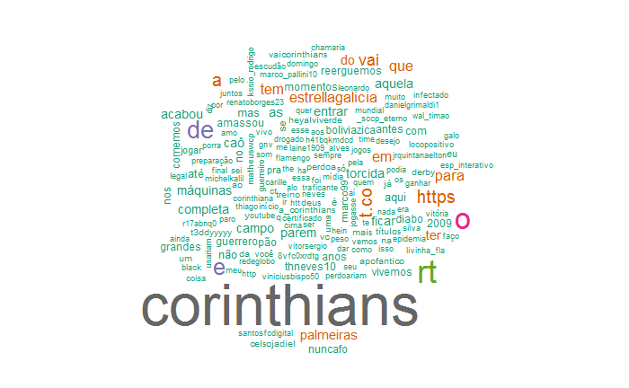

```r
top_sccp <- top_words %>%
  filter(clube == "Corinthians")

wordcloud(top_sccp$term, top_sccp$n, colors = brewer.pal(8, "Dark2"))
```

### Palmeiras

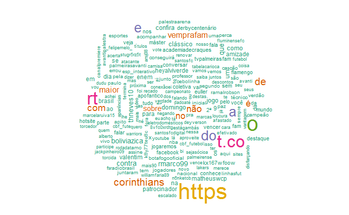

```r
top_sep <- top_words %>%
  filter(clube == "Palmeiras")

wordcloud(top_sep$term, top_sep$n, colors = brewer.pal(8, "Dark2"))
```

### Santos

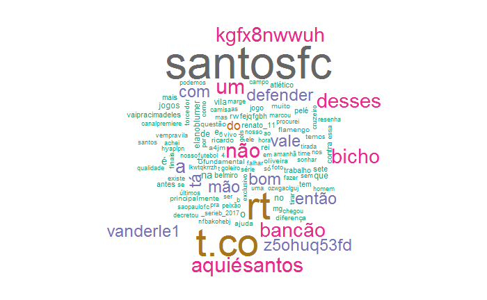

```r
top_sfc <- top_words %>%
  filter(clube == "Santos")

wordcloud(top_sfc$term, top_sfc$n, colors = brewer.pal(8, "Dark2"))
```

### São Paulo

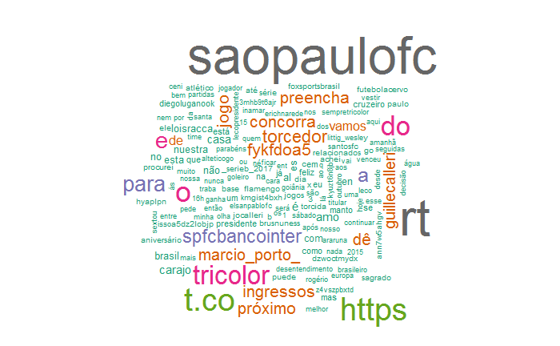

```r
top_spfc <- top_words %>%
  filter(clube == "São Paulo")

wordcloud(top_spfc$term, top_spfc$n, colors = brewer.pal(8, "Dark2"))
```

## Análise de Sentimento

Cada palavra carrega consigo um sentimento que pode ser bom (1), neutro (0) ou ruim (-1). Vamos ver o sentimento transmitidos por algumas palavras.

```r
dicio <- oplexicon_v3.0 # Carrega dicionário de sentimentos
# Cinco palavras aleatórias
dicio[sample(1:nrow(dicio), 5) ,]
```

|  | term | type | polarity | polarity_revision |
| --- | --- | --- | --- | --- |
| 7302 | comentadora | adj | 0 | A |
| 7061 | claustrofobica | adj | -1 | M |
| 26271 | pudibundo | adj | 0 | A |
| 22732 | monstruosos | adj | -1 | M |
| 28346 | russofila | adj | 0 | A |

### Corinthians

```r
# Análise de sentimento dos tweets referentes ao Corinthians
sentimento_sccp <- tweets_clubes %>%
  filter(clube == "Corinthians") %>%  # Apenas tweets referentes ao Corinthians
  unnest_tokens(term, text) %>%       # Quebra os tweets em palavras
  inner_join(dicio) %>%
  count(term, polarity, sort = TRUE) %>%
  ungroup()
sentimento_sccp
```

| term | polarity | n |
| --- | --- | --- |
| ter | 0 | 31 |
| entrar | -1 | 27 |
| ficar | 1 | 27 |
| completa | 0 | 26 |
| torcida | -1 | 26 |
| mas | -1 | 22 |
| grandes | 0 | 15 |
| jogar | 1 | 11 |
| drogado | -1 | 5 |
| guerreiro | 0 | 5 |

[output cut: 71 more lines]

### Palmeiras

```r
# Análise de sentimento dos tweets referentes ao Palmeiras
sentimento_sep <- tweets_clubes %>%
  filter(clube == "Palmeiras") %>%  # Apenas tweets referentes ao Corinthians
  unnest_tokens(term, text) %>%     # Quebra os tweets em palavras
  inner_join(dicio) %>%
  count(term, polarity, sort = TRUE) %>%
  ungroup()
sentimento_sep
```

| term | polarity | n |
| --- | --- | --- |
| maior | 0 | 30 |
| falar | 0 | 11 |
| coletiva | 0 | 10 |
| conversar | 1 | 10 |
| mundo | 1 | 10 |
| vencer | -1 | 10 |
| vivo | 1 | 9 |
| ser | 1 | 8 |
| inicial | 0 | 7 |
| acompanhar | 0 | 6 |

[output cut: 90 more lines]

### Santos

```r
# Análise de sentimento dos tweets referentes ao Santos
sentimento_sfc <- tweets_clubes %>%
  filter(clube == "Santos") %>%  # Apenas tweets referentes ao Corinthians
  unnest_tokens(term, text) %>%     # Quebra os tweets em palavras
  inner_join(dicio) %>%
  count(term, polarity, sort = TRUE) %>%
  ungroup()
sentimento_sfc
```

| term | polarity | n |
| --- | --- | --- |
| bom | 1 | 56 |
| defender | -1 | 56 |
| vila | -1 | 15 |
| finais | 0 | 7 |
| torcedor | 0 | 7 |
| fundamental | 0 | 6 |
| mas | -1 | 5 |
| tirar | 0 | 5 |
| fazer | 0 | 4 |
| sonhar | 0 | 4 |

[output cut: 40 more lines]

### São Paulo

```r
# Análise de sentimento dos tweets referentes ao Corinthians
sentimento_spfc <- tweets_clubes %>%
  filter(clube == "São Paulo") %>%  # Apenas tweets referentes ao Corinthians
  unnest_tokens(term, text) %>%     # Quebra os tweets em palavras
  inner_join(dicio) %>%
  count(term, polarity, sort = TRUE) %>%
  ungroup()
sentimento_spfc
```

| term | polarity | n |
| --- | --- | --- |
| torcedor | 0 | 49 |
| mas | -1 | 11 |
| titular | 1 | 10 |
| feliz | 1 | 9 |
| presidente | 0 | 9 |
| sagrado | 1 | 7 |
| relacionados | -1 | 6 |
| torcida | -1 | 6 |
| continuar | 1 | 5 |
| partidas | -1 | 4 |

[output cut: 52 more lines]

### Sentimento Geral

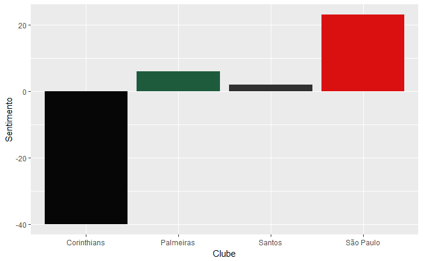

```r
tweets_clubes %>%
  unnest_tokens(term, text) %>%
  inner_join(dicio) %>%
  group_by(clube) %>%
  summarise(sum(polarity)) %>%
  ggplot(aes(clube, `sum(polarity)`, fill = clube)) +
  geom_col(show.legend = FALSE) +
  scale_fill_manual(values = c("#060606", "#1e5b3c", "#313030", "#da1010")) +
  labs(x = "Clube", y = "Sentimento")
```

## Calculando a Frequência das Palavras (TF)

Vamos calcular a frequência das palavras dentro dos Twitters dos clubes:

```r
texto_clubes <- tweets_clubes %>%
  unnest_tokens(termo, text) %>%
  count(clube, termo, sort = TRUE) %>%
  ungroup()
total_texto_clubes <- texto_clubes %>%
  group_by(clube) %>%
  summarize(total = sum(n))
texto_clubes <- left_join(texto_clubes, total_texto_clubes)
texto_clubes
```

| clube | termo | n | total |
| --- | --- | --- | --- |
| Corinthians | corinthians | 236 | 2941 |
| Palmeiras | palmeiras | 210 | 3301 |
| Santos | santosfc | 200 | 2728 |
| São Paulo | saopaulofc | 200 | 3057 |
| São Paulo | rt | 198 | 3057 |
| Santos | https | 174 | 2728 |
| Santos | rt | 172 | 2728 |
| Santos | t.co | 170 | 2728 |
| Palmeiras | https | 138 | 3301 |
| Palmeiras | o | 129 | 3301 |

[output cut: 990 more lines]

Agora, realizarmos o calculo da Frequencia dos Termos (TF) por time:

```r
tf_texto_clubes_by_rank <- texto_clubes %>%
  group_by(clube) %>%
  mutate(rank = row_number(),
         `TF` = n/total)
tf_texto_clubes_by_rank
```

| clube | termo | n | total | rank | TF |
| --- | --- | --- | --- | --- | --- |
| Corinthians | corinthians | 236 | 2941 | 1 | 0.0802448147 |
| Palmeiras | palmeiras | 210 | 3301 | 1 | 0.0636170857 |
| Santos | santosfc | 200 | 2728 | 1 | 0.0733137830 |
| São Paulo | saopaulofc | 200 | 3057 | 1 | 0.0654236179 |
| São Paulo | rt | 198 | 3057 | 2 | 0.0647693817 |
| Santos | https | 174 | 2728 | 2 | 0.0637829912 |
| Santos | rt | 172 | 2728 | 3 | 0.0630498534 |
| Santos | t.co | 170 | 2728 | 4 | 0.0623167155 |
| Palmeiras | https | 138 | 3301 | 2 | 0.0418055135 |
| Palmeiras | o | 129 | 3301 | 3 | 0.0390790669 |

[output cut: 990 more lines]

E por fim, plotando os termos:

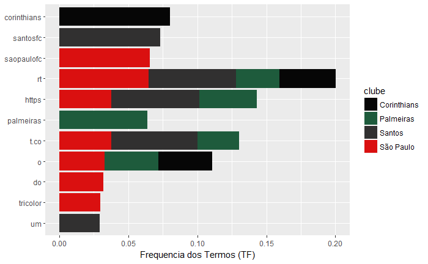

```r
plot_clubes_tf <- tf_texto_clubes_by_rank %>%
  ungroup(tf_texto_clubes_by_rank) %>%
  arrange(desc(TF)) %>%
  mutate(termo = factor(termo, levels = rev(unique(termo))))
plot_clubes_tf %>%
  top_n(20) %>%
  ggplot(aes(termo, TF, fill = clube)) +
  scale_fill_manual(values=c("#060606", "#1e5b3c", "#313030", "#da1010")) +
  geom_col() +
  labs(x = NULL, y = "Frequencia dos Termos (TF)") +
  coord_flip()
```

## Calculando a Freqüência Inversa no Documento (IDF)

Sparck Jones desenvolveu uma interpretação estatística da especificidade dos termos (1972), chamada de IDF.

```r
texto_clubes_tf_idf <- texto_clubes %>%
  bind_tf_idf(termo, clube, n)
texto_clubes_tf_idf
```

| clube | termo | n | total | tf | idf | tf_idf |
| --- | --- | --- | --- | --- | --- | --- |
| Corinthians | corinthians | 236 | 2941 | 0.0802448147 | 0.2876821 | 2.308499e-02 |
| Palmeiras | palmeiras | 210 | 3301 | 0.0636170857 | 0.6931472 | 4.409600e-02 |
| Santos | santosfc | 200 | 2728 | 0.0733137830 | 0.2876821 | 2.109106e-02 |
| São Paulo | saopaulofc | 200 | 3057 | 0.0654236179 | 0.6931472 | 4.534820e-02 |
| São Paulo | rt | 198 | 3057 | 0.0647693817 | 0.0000000 | 0.000000e+00 |
| Santos | https | 174 | 2728 | 0.0637829912 | 0.0000000 | 0.000000e+00 |
| Santos | rt | 172 | 2728 | 0.0630498534 | 0.0000000 | 0.000000e+00 |
| Santos | t.co | 170 | 2728 | 0.0623167155 | 0.0000000 | 0.000000e+00 |
| Palmeiras | https | 138 | 3301 | 0.0418055135 | 0.0000000 | 0.000000e+00 |
| Palmeiras | o | 129 | 3301 | 0.0390790669 | 0.0000000 | 0.000000e+00 |

[output cut: 990 more lines]

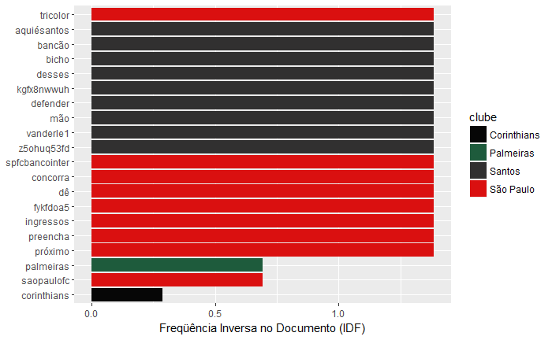

```r
plot_clubes_idf <- texto_clubes_tf_idf %>%
  ungroup(texto_clubes_tf_idf) %>%
  arrange(desc(idf)) %>%
  mutate(termo = factor(termo, levels = rev(unique(termo))))
plot_clubes_idf %>%
  top_n(20) %>%
  ggplot(aes(termo, idf, fill = clube)) +
  scale_fill_manual(values=c("#060606", "#1e5b3c", "#313030", "#da1010")) +
  geom_col() +
  labs(x = NULL, y = "Freqüência Inversa no Documento (IDF)") +
  coord_flip()
```

## Calculando a ponderação TF-IDF

```r
texto_clubes_tf_idf %>%
  select(-total) %>%
  arrange(desc(tf_idf))
```

| clube | termo | n | tf | idf | tf_idf |
| --- | --- | --- | --- | --- | --- |
| São Paulo | saopaulofc | 200 | 0.0654236179 | 0.6931472 | 0.0453481963 |
| Palmeiras | palmeiras | 210 | 0.0636170857 | 0.6931472 | 0.0440960036 |
| São Paulo | tricolor | 91 | 0.0297677462 | 1.3862944 | 0.0412668586 |
| Santos | aquiésantos | 79 | 0.0289589443 | 1.3862944 | 0.0401456212 |
| Santos | bancão | 76 | 0.0278592375 | 1.3862944 | 0.0386211039 |
| Santos | bicho | 76 | 0.0278592375 | 1.3862944 | 0.0386211039 |
| Santos | desses | 76 | 0.0278592375 | 1.3862944 | 0.0386211039 |
| Santos | kgfx8nwwuh | 76 | 0.0278592375 | 1.3862944 | 0.0386211039 |
| Santos | defender | 56 | 0.0205278592 | 1.3862944 | 0.0284576555 |
| Santos | mão | 56 | 0.0205278592 | 1.3862944 | 0.0284576555 |

[output cut: 990 more lines]

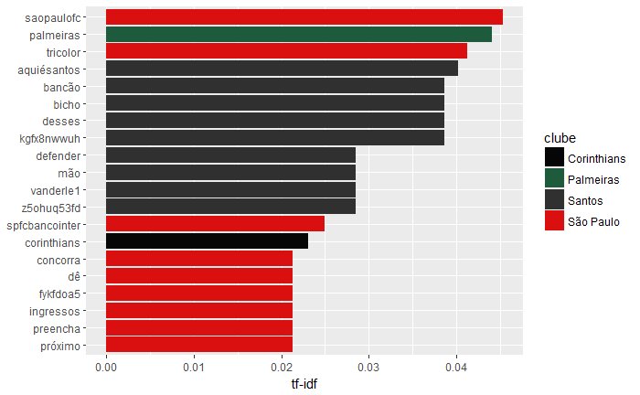

```r
plot_clubes_tf_idf <- texto_clubes_tf_idf %>%
  arrange(desc(tf_idf)) %>%
  mutate(termo = factor(termo, levels = rev(unique(termo))))
plot_clubes_tf_idf %>%
  top_n(20) %>%
  ggplot(aes(termo, tf_idf, fill = clube)) +
  scale_fill_manual(values=c("#060606", "#1e5b3c", "#313030", "#da1010")) +
  geom_col() +
  labs(x = NULL, y = "tf-idf") +
  coord_flip()
```

Agora, para cada clube:

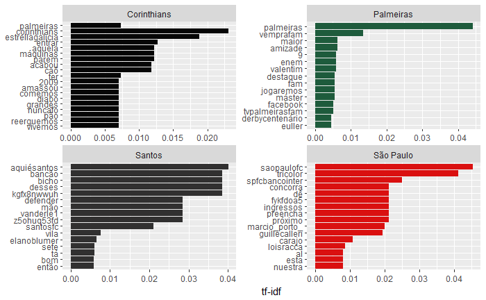

```r
plot_clubes_tf_idf %>%
  group_by(clube) %>%
  top_n(15) %>%
  ungroup %>%
  ggplot(aes(termo, tf_idf, fill = clube)) +
  scale_fill_manual(values=c("#060606", "#1e5b3c", "#313030", "#da1010")) +
  geom_col(show.legend = FALSE) +
  labs(x = NULL, y = "tf-idf") +
  facet_wrap(~clube, ncol = 2, scales = "free") +
  coord_flip()
```

## Bigrama

Abaixo, vamos calcular o Bigrama:

```r
bigramas_tweets_clubes <- tweets_clubes %>%
  unnest_tokens(bigrama, text, token = "ngrams", n = 2)
bigramas_tweets_clubes
```

| clube | created_at | bigrama |
| --- | --- | --- |
| Corinthians | 2017-11-03 17:47:35 | rt renatoborges23 |
| Corinthians | 2017-11-03 17:47:35 | renatoborges23 podia |
| Corinthians | 2017-11-03 17:47:35 | podia ter |
| Corinthians | 2017-11-03 17:47:35 | ter escudã£o |
| Corinthians | 2017-11-03 17:47:35 | escudã£o do |
| Corinthians | 2017-11-03 17:47:35 | do corinthians |
| Corinthians | 2017-11-03 17:47:35 | corinthians domingo |
| Corinthians | 2017-11-03 17:47:35 | domingo hein |
| Corinthians | 2017-11-03 17:47:35 | hein alo |
| Corinthians | 2017-11-03 17:47:35 | alo corinthians |

[output cut: 990 more lines]

Recalculando o TF-IDF com o Bigrama:

```r
bigramas_tweets_texto_clubes <- bigramas_tweets_clubes %>%
  count(clube, bigrama, sort = TRUE) %>%
  ungroup()
total_bigramas_tweets_texto_clubes <- bigramas_tweets_texto_clubes %>%
  group_by(clube) %>%
  summarize(total = sum(n))
bigramas_tweets_texto_clubes <- left_join(bigramas_tweets_texto_clubes, total_bigramas_tweets_texto_clubes)
bigramas_tweets_texto_clubes_tf_idf <- bigramas_tweets_texto_clubes %>%
  bind_tf_idf(bigrama, clube, n)
bigramas_tweets_texto_clubes_tf_idf %>%
  select(-total) %>%
  arrange(desc(tf_idf))
```

| clube | bigrama | n | tf | idf | tf_idf |
| --- | --- | --- | --- | --- | --- |
| Santos | rt santosfc | 162 | 0.0635543350 | 1.3862944 | 0.0881050163 |
| Corinthians | rt corinthians | 92 | 0.0334788937 | 1.3862944 | 0.0464116016 |
| Santos | aquiã‰santos https | 79 | 0.0309925461 | 1.3862944 | 0.0429647919 |
| Santos | bancã£o desses | 76 | 0.0298156140 | 1.3862944 | 0.0413332175 |
| Santos | bicho aquiã‰santos | 76 | 0.0298156140 | 1.3862944 | 0.0413332175 |
| Santos | desses bicho | 76 | 0.0298156140 | 1.3862944 | 0.0413332175 |
| Santos | santosfc um | 76 | 0.0298156140 | 1.3862944 | 0.0413332175 |
| Santos | t.co kgfx8nwwuh | 76 | 0.0298156140 | 1.3862944 | 0.0413332175 |
| Santos | um bancã£o | 76 | 0.0298156140 | 1.3862944 | 0.0413332175 |
| Santos | santosfc nã£o | 59 | 0.0231463319 | 1.3862944 | 0.0320876294 |

[output cut: 990 more lines]

Vamos vê os plotes para cada clube:

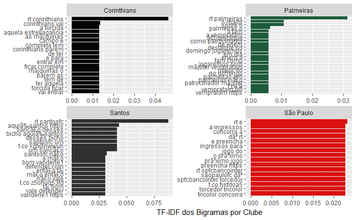

```r
plot_clubes_tf_idf_bigrama <- bigramas_tweets_texto_clubes_tf_idf %>%
  arrange(desc(tf_idf)) %>%
  mutate(bigrama = factor(bigrama, levels = rev(unique(bigrama))))
plot_clubes_tf_idf_bigrama %>%
  group_by(clube) %>%
  top_n(15) %>%
  ungroup %>%
  ggplot(aes(bigrama, tf_idf, fill = clube)) +
  geom_col(show.legend = FALSE) +
  labs(x = NULL, y = "TF-IDF dos Bigramas por Clube") +
  scale_fill_manual(values=c("#060606", "#1e5b3c", "#313030", "#da1010")) +
  facet_wrap(~clube, ncol = 2, scales = "free") +
  coord_flip()
```

Visualização com nuvem de palavras das 100 bigramas com maior tf-idf de cada clube:

### Corinthians

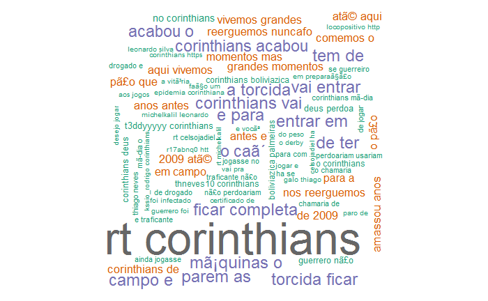

```r
top_sccp_bigramas_tf_idf <- bigramas_tweets_texto_clubes_tf_idf %>%
  filter(clube == "Corinthians")

wordcloud(top_sccp_bigramas_tf_idf$bigrama, top_sccp_bigramas_tf_idf$tf_idf, colors = brewer.pal(8, "Dark2"), max.words= 100)
```

### Palmeiras

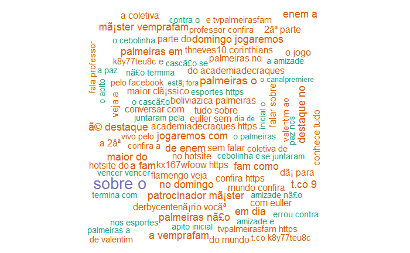

```r
top_sep_bigramas_tf_idf <- bigramas_tweets_texto_clubes_tf_idf %>%
  filter(clube == "Palmeiras")

wordcloud(top_sep_bigramas_tf_idf$bigrama, top_sep_bigramas_tf_idf$tf_idf, colors = brewer.pal(8, "Dark2"), max.words= 100)
```

### Santos

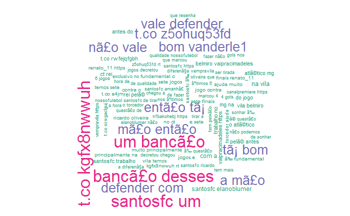

```r
top_sfc_bigramas_tf_idf <- bigramas_tweets_texto_clubes_tf_idf %>%
  filter(clube == "Santos")

wordcloud(top_sfc_bigramas_tf_idf$bigrama, top_sfc_bigramas_tf_idf$tf_idf, colors = brewer.pal(8, "Dark2"), max.words= 100)
```

### São Paulo

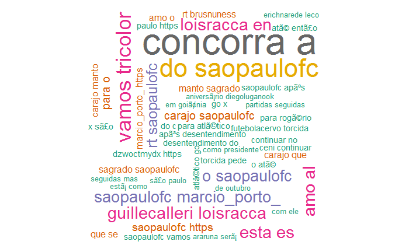

```r
top_spfc_bigramas_tf_idf <- bigramas_tweets_texto_clubes_tf_idf %>%
  filter(clube == "São Paulo")

wordcloud(top_spfc_bigramas_tf_idf$bigrama, top_spfc_bigramas_tf_idf$tf_idf, colors = brewer.pal(8, "Dark2"), max.words= 100)
```

## Referências

- [Cliente R para API do Twitter](https://github.com/mkearney/rtweet)
- [Text Mining With R](http://tidytextmining.com/)